# The Central Limit Theorem

2024

## Introduction

- The **Central Limit Theorem (CLT)** is a fundamental theorem in statistics that describes the distribution of sample means.
- It explains why many distributions tend to be close to a normal distribution, especially as the sample size increases.
- The CLT is crucial for conducting hypothesis tests and constructing confidence intervals in many practical situations.

## Understanding the CLT

- **Definition:** The CLT states that the distribution of the sample means of a large number of independent, identically distributed variables will be approximately normal, regardless of the shape of the original distribution.
- **Assumptions:**
  - The samples are independent.
  - The samples are identically distributed, meaning each sample is drawn from the same distribution.
  - The sample size is sufficiently large (usually n > 30 is considered large enough).

## Demonstration of the CLT 1

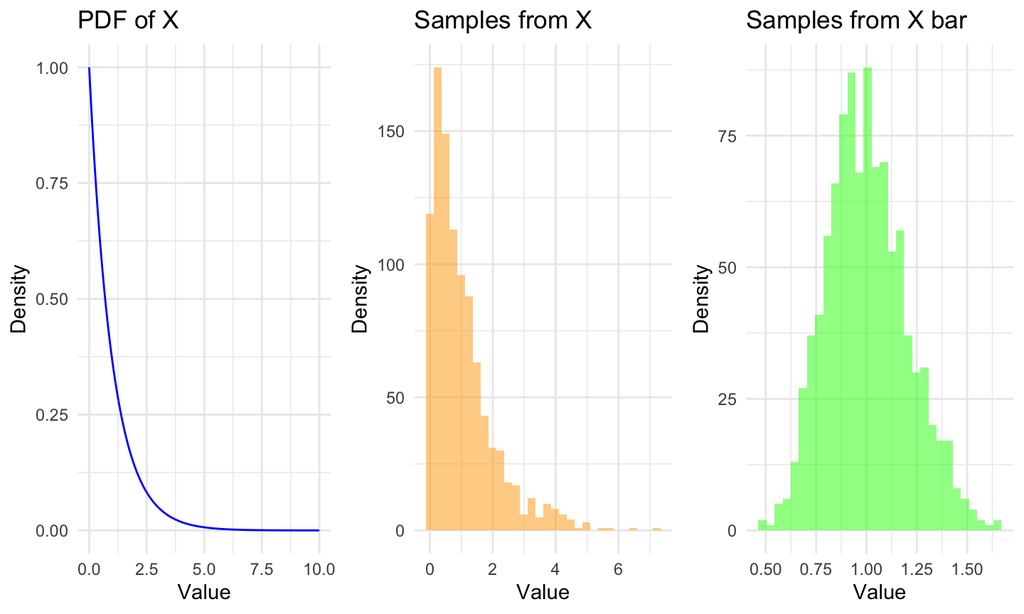

## Demonstration of the CLT 2

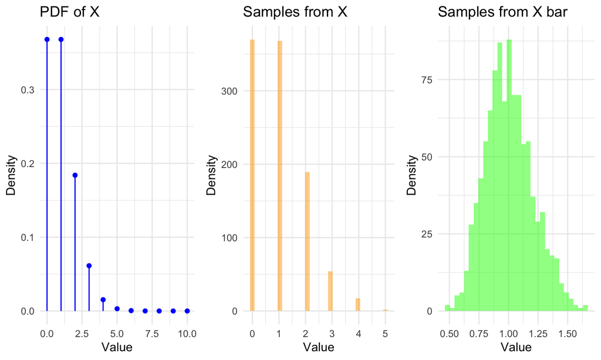

## Significance of the CLT

- **Importantance:** The CLT is important because it justifies the practice of assuming a normal distribution for inferential statistics, even when the population distribution is unknown.
- **Applications:**
  - It is used in hypothesis testing to determine if there is a significant difference between groups.
  - In constructing confidence intervals for estimating population parameters.
  - Simplifying complex probability problems into manageable calculations using the normal distribution.

## The Math Behind the CLT

- **Mathematical Formulation:** If \(X_1, X_2, ..., X_n\) are \(n\) independent, identically distributed (i.i.d.) random variables with mean \(\mu\) and variance \(\sigma^2\), then the sample mean \(\bar{X} = \frac{1}{n}\sum_{i=1}^{n}X_i\) will have a distribution that approaches a normal distribution \(N(\mu, \frac{\sigma^2}{n})\) as \(n\) approaches infinity.
- **Simplified Explanation:** No matter what the original distribution looks like, the distribution of the sample means will tend to look more like a normal distribution as the number of samples increases. This holds true even for non-normal distributions.

## Central limit theorem mean and variance

- One way to see where the mean and variance parameters come from in the central limit theorem is to use the following rule:

\[ \begin{align} \text{Let} Y &\sim a X + b \\ \mathbb{E}\big[Y\big] &= a \mathbb{E}\big[X\big] + \mathbb{E}(b) \\ \mathbb{Var}\big[Y\big] &= (a^2) \mathbb{Var}\big[X\big] \\ \end{align} \]

## Applied to the distribution of sample sums

\[ \begin{align} \boldsymbol{Y} &= \boldsymbol{X}_1 + \boldsymbol{X}_2 + \dots + \boldsymbol{X}_n \\ \\ E(\boldsymbol{Y}) &= E(\boldsymbol{X}_1 + \boldsymbol{X}_2 + \dots + \boldsymbol{X}_n) \\ &= E(\boldsymbol{X}_1) + E(\boldsymbol{X}_2) + \dots + E(\boldsymbol{X}_n) \\ &= \mu_x + \mu_x + \ldots + \mu_x \\ &= n \mu_x \\ \end{align} \]

\[ \begin{align} Var(\boldsymbol{Y}) &= Var(\boldsymbol{X}_1 + \boldsymbol{X}_2 + \dots + \boldsymbol{X}_n) \\ &= Var(\boldsymbol{X}_1) + Var(\boldsymbol{X}_2) + \dots + Var(\boldsymbol{X}_n) \\ &= \sigma_x^2 + \sigma_x^2 + \dots + \sigma_x^2 \\ &= n \sigma_x^2 \\ \end{align} \]

\[ \begin{align} \mu_{Y} &= n \mu_{X} \\ \sigma_Y^2 &= n \sigma_X^2 \\ \end{align} \]

## Applied to the distribution of sample means

\[ \begin{align} \boldsymbol{Y} &= \frac{1}{n} (\boldsymbol{X}_1 + \boldsymbol{X}_2 + \dots + \boldsymbol{X}_n) \\ \\ E(\boldsymbol{Y}) &= E(\frac{1}{n} (\boldsymbol{X}_1 + \boldsymbol{X}_2 + \dots + \boldsymbol{X}_n)) \\ &= \frac{1}{n} (E(\boldsymbol{X}_1) + E(\boldsymbol{X}_2) + \dots + E(\boldsymbol{X}_n)) \\ &= \frac{1}{n} (\mu_x + \mu_x + \ldots + \mu_x) \\ &= \mu_x \\ \end{align} \]

\[ \begin{align} Var(\boldsymbol{Y}) &= Var(\frac{1}{n} (\boldsymbol{X}_1 + \boldsymbol{X}_2 + \dots + \boldsymbol{X}_n)) \\ &= Var(\frac{1}{n^2} (Var(\boldsymbol{X}_1) + Var(\boldsymbol{X}_2) + \dots + Var(\boldsymbol{X}_n)) \\ &= \frac{1}{n^2} ( \sigma_x^2 + \sigma_x^2 + \dots + \sigma_x^2 ) \\ &= \frac{1}{n} \sigma_x^2 \\ \end{align} \]

\[ \begin{align} \mu_{Y} &= \mu_{X} \\ \sigma_Y^2 &= \frac{1}{n} \sigma_X^2 \\ \end{align} \]

## Standard Error

- When applying the central limit theorem to the distribution of sample means, we get:

\[ \begin{align} \mu_{Y} &= \mu_{X} \\ \sigma_Y^2 &= \frac{1}{n} \sigma_X^2 \\ \end{align} \]

- When expressed in terms of standard deviation:

\[ \begin{align} \mu_{Y} &= \mu_{X} \\ \sigma_y &= \frac{1}{\sqrt{n}} \sigma_X \\ \end{align} \]

Here, \(\sigma_Y\) is called the **standard error of the mean (SEM)** and it is very commonly used to draw error bars on various plots.

## Question

What does the Central Limit Theorem (CLT) state about the distribution of sample means?

- The distribution of sample means will approach a uniform distribution as the sample size increases.
- The distribution of sample means will be skewed towards the left or right depending on the population distribution.
- The distribution of sample means will approach a normal distribution as the sample size increases, regardless of the population distribution.
- The distribution of sample means is irrelevant to the shape of the population distribution.

**Answer**

**Correct Answer:** The Central Limit Theorem states that, given a sufficiently large sample size, the distribution of sample means will be approximately normally distributed, regardless of the shape of the population distribution.